# PAINTING

Damiano Fumagalli

2022-04-08

```r
library(dplyr)
library(tidyr)
library(gapminder)
```

```r
library(ggplot2)
library(stringr)
```

# CERCHIO

> DISEGNARE DEI PUNTI LUNGO LA CIRCONFERENZA

## GEOM_POINT()

> È UNA FUNZIONE CHE PERMETTE DI GENERARE UN PUNTO SUL PIANO CARTESIANO DATE DUE COORDINATE (X , Y)

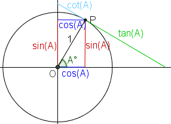

immagine

> LA CIRCONFERENZA GONIOMETRICA HA COME RAGGIO = 1
- **DISEGNARE DEI PUNTI SULLA CIRCONFERENZA EQUIDISTANTI CON UN ANGOLO INTERMEDIO DI (piGreco / 8)rad = 180°/8 = 22,5°**

## GONIOMETRIA

- R = raggio Cerchio
- alfa = angolo
- P = (a,b) appartenente a (R,R) = PIANO R^2
- a = ascissa(x) del punto P
  - a = R * cos(alfa)
- b = ordinata(y) del punto P
  - b = R * sin(alfa)

```r
# RAGGIO CIRCONFERENZA GONIOMETRICA
R = 1
# LISTA DI ANGOLI ESPRESSI IN RADIANTI
(angoli = seq(0,2*pi,length.out = 17))
```

```
##  [1] 0.0000000 0.3926991 0.7853982 1.1780972 1.5707963 1.9634954 2.3561945
##  [8] 2.7488936 3.1415927 3.5342917 3.9269908 4.3196899 4.7123890 5.1050881
## [15] 5.4977871 5.8904862 6.2831853
```

```r
# A = {a1,a2,...,a17}: ai= R * cos(angoli[i])
(A = R*cos(angoli))
```

```
##  [1]  1.000000e+00  9.238795e-01  7.071068e-01  3.826834e-01  6.123032e-17
##  [6] -3.826834e-01 -7.071068e-01 -9.238795e-01 -1.000000e+00 -9.238795e-01
## [11] -7.071068e-01 -3.826834e-01 -1.836910e-16  3.826834e-01  7.071068e-01
## [16]  9.238795e-01  1.000000e+00
```

```r
# B = {b1,b2,...,b17}: bi = R*sin(angoli[i])
(B = R*sin(angoli))
```

```
##  [1]  0.000000e+00  3.826834e-01  7.071068e-01  9.238795e-01  1.000000e+00
##  [6]  9.238795e-01  7.071068e-01  3.826834e-01  1.224606e-16 -3.826834e-01
## [11] -7.071068e-01 -9.238795e-01 -1.000000e+00 -9.238795e-01 -7.071068e-01
## [16] -3.826834e-01 -2.449213e-16
```

> UNA VOLTA OTTENUTE L’INSIEME DELLE COORDINATE SI CREA UN DATAFRAME

```r
(DF = data.frame(angoli,A,B))
```

```
##       angoli             A             B
## 1  0.0000000  1.000000e+00  0.000000e+00
## 2  0.3926991  9.238795e-01  3.826834e-01
## 3  0.7853982  7.071068e-01  7.071068e-01
## 4  1.1780972  3.826834e-01  9.238795e-01
## 5  1.5707963  6.123032e-17  1.000000e+00
## 6  1.9634954 -3.826834e-01  9.238795e-01
## 7  2.3561945 -7.071068e-01  7.071068e-01
## 8  2.7488936 -9.238795e-01  3.826834e-01
## 9  3.1415927 -1.000000e+00  1.224606e-16
## 10 3.5342917 -9.238795e-01 -3.826834e-01
## 11 3.9269908 -7.071068e-01 -7.071068e-01
## 12 4.3196899 -3.826834e-01 -9.238795e-01
## 13 4.7123890 -1.836910e-16 -1.000000e+00
## 14 5.1050881  3.826834e-01 -9.238795e-01
## 15 5.4977871  7.071068e-01 -7.071068e-01
## 16 5.8904862  9.238795e-01 -3.826834e-01
## 17 6.2831853  1.000000e+00 -2.449213e-16
```

## GRAFICO

> **GRAZIE ALLE FUNZIONI DI LIBRERIA DI ggplot2 È POSSIBILE GENERARE UN GRAFICO, DEFINITO SCATTERPLOT, CON I DATI DELLA TABELLA CREATA**

```r
base = ggplot(data = DF, aes(A,B))
```

> LA BASE DEL GRAFICO CORRISPONDE ALLA DEFINIZIONE DEGLI INTERVALLI DEL DOMINIO E CODOMINIO NEI QUALI VERRANNO VISUALIZZATI I PUNTI DEFINITI

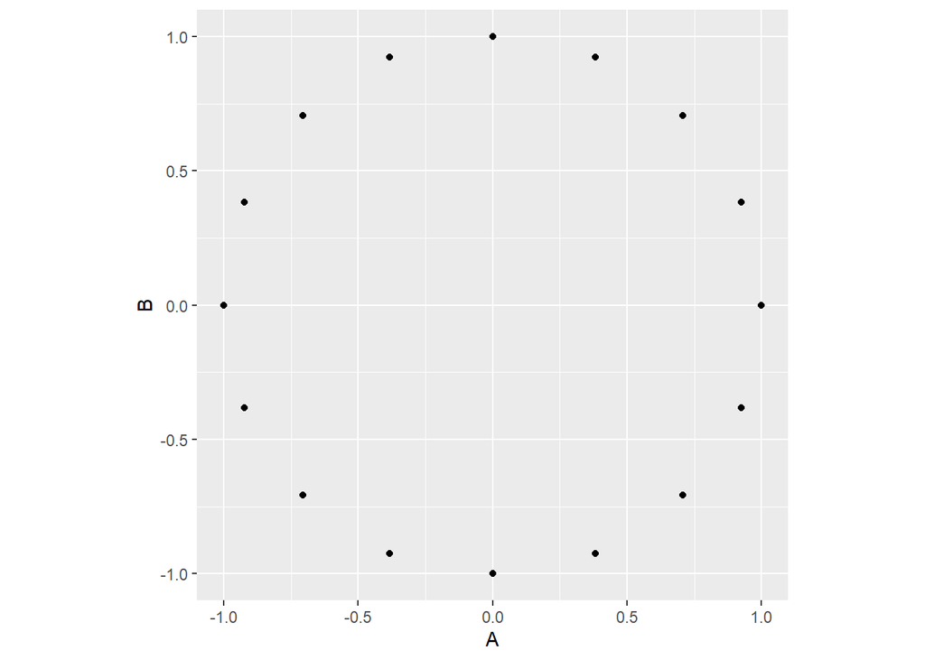

```r
base + geom_point(aes(x = A,y=B)) + coord_fixed()
```

> **GEOM_POINT() DEFINISCE I PUNTI CHE DEVONO ESSERE VISUALIZZATI, COORD_FIXED() DEFINISCE UNA SCALA FISSA PER RAPPRESENTARE IL GRAFICO, E NON LO ADATTA ALLE DIMENSIONI DELLO SCHERMO**

# GOLDEN RATIO

> DISEGNARE UNA SPIRALE AUREA TENENDO CONTO DELL’ANGOLO AURE = GOLDEN RATIO = piGreco*(3-sqrt(5))

```r
# ESPRESSO IN RADIANTI
(GoldRatioRads = pi*(3-sqrt(5)))
```

```
## [1] 2.399963
```

```r
(GoldRatioDegs = 180*(3-sqrt(5)))
```

```
## [1] 137.5078
```

```r
# fattore conversione GRADI --> RADIANTI
DegsToRads = 2*pi/360
GoldRatioRads == GoldRatioDegs*DegsToRads
```

```
## [1] TRUE
```

```r
# fattore conversione RADIANTI --> GRADI
RadsToDegs = 360/(2*pi)
GoldRatioDegs == GoldRatioRads*RadsToDegs
```

```
## [1] TRUE
```

> OTTENUTI GLI ANGOLI ORA È POSSIBILE CREARE IL GRAFICO

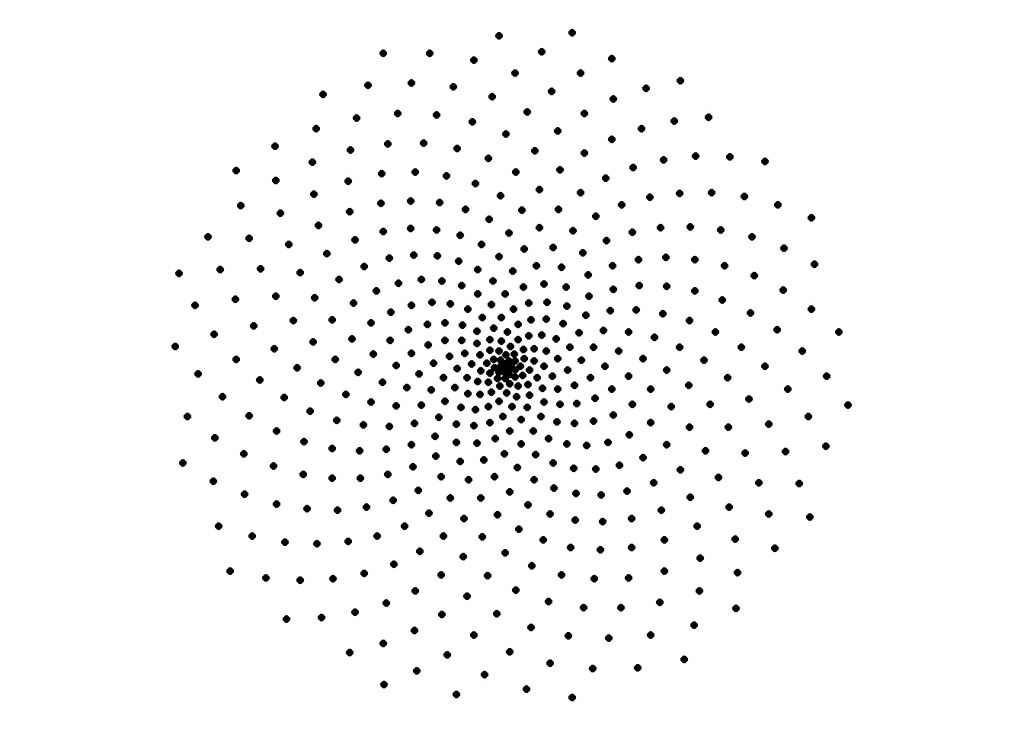

```r
# numero di puntini da disegnare
points = 500
T = (1:points)*GoldRatioRads
A = cos(T)
B = sin(T)
df = data.frame(T,A,B)
ggplot(df, aes(A*T,B*T)) +
  geom_point() +
  coord_fixed() +
  theme_void()
```

# COLORAZIONE

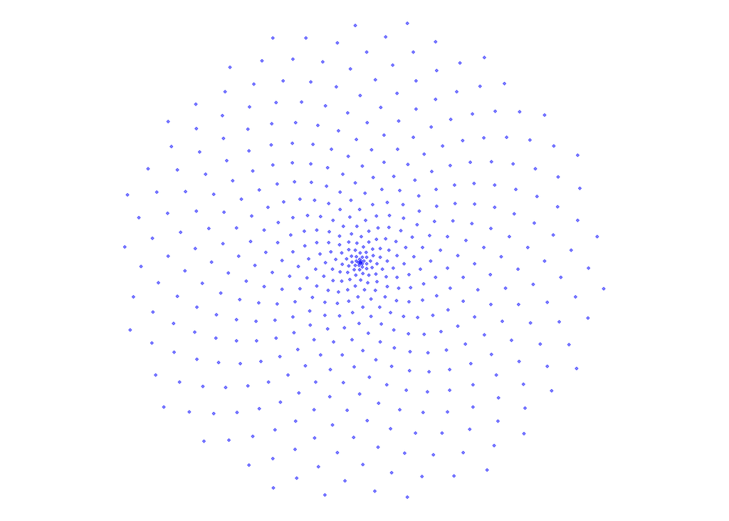

```r
ggplot(df, aes(A*T,B*T)) +
  geom_point(show.legend = FALSE,alpha = 0.5, size = 0.8, color = "blue") + coord_fixed() + theme_void()
```

# DIMENSIONE VARIABILE

> I PUNTI FINORA POSSIEDONO TUTTI LA STESSA CARATTERISTICA. TALVOLTA PERò È OPPORTUNO CAMBIARE L’ASPETTO IN BASE AL VALORE DI DETERMINATE VARIABILI DEL DATAFRAME
- COLORE = NERO
- SHAPE = “*” = 8
- MAPPARE LA DIMENSIONE DEI PUNTI NELLA VARIABILE T DEL DATAFRAME

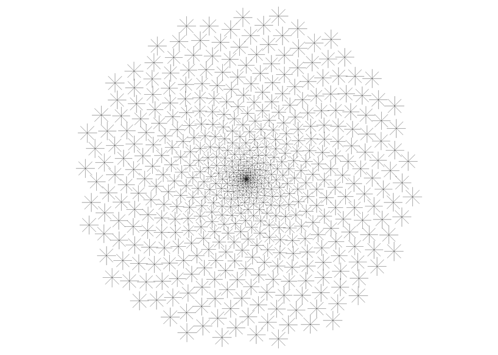

```r
ggplot(df, aes(A*T,B*T)) +
  geom_point(color = "black", shape = 8, aes(size = T),show.legend = FALSE,alpha=0.5) + coord_fixed() + theme_void()
```